# Dissenys niats

Antonio Miñarro (aminarro@ub.edu)

17 novembre, 2025

# 1 Dissenys niats o jerarquitzats

## 1.1 Exemple 1: Nivell de glicogen en múscul

- En un determinat estudi es desitja comparar el nivell de glicogen en el múscul gastrocnemi (els bessons) de rates estressades i no estressades. El nivell de estrès és el tractament.
- Les rates estan disposades en gàbies de 3 en 3. Les rates de la gàbia reben totes el mateix tractament i son homogènies en edat, pes i sexe. Hi ha un total de 3 gàbies per tractament. La Gàbia representa un factor bloc. **Observem que cada gàbia rep un sol tractament**
- Les 6 gàbies s’escullen a l’atzar dins l’estabulari, s’aleatoritzen abans de començar l’experiment respecte al tractament.
- La variable resposta és igual a grams de glicogen per 100 grams de múscul.

Les dades són les següents:

$$\begin{array}{|cc|ccc|} \hline
\mbox{Tractament}&\mbox{Gàbia}&\mbox{Rata 1}&\mbox{Rata
2}&\mbox{Rata 3}\\ \hline
\mbox{Estrès}&1&0.55&0.61&0.49 \\
\mbox{Estrès}&2&0.59&0.65&0.39 \\
\mbox{Estrès}&3&0.48&0.59&0.41 \\ \hline
\mbox{Control}&4&0.11&0.20&0.09 \\
\mbox{Control}&5&0.12&0.09&0.09 \\
\mbox{Control}&6&0.22&0.30&0.20 \\ \hline \end{array}$$

Tenim tres fons de variabilitat:

1. Tractament (controlada)
2. Gàbia (controlada)
3. Rata

## 1.2 Descriptiva de les dades

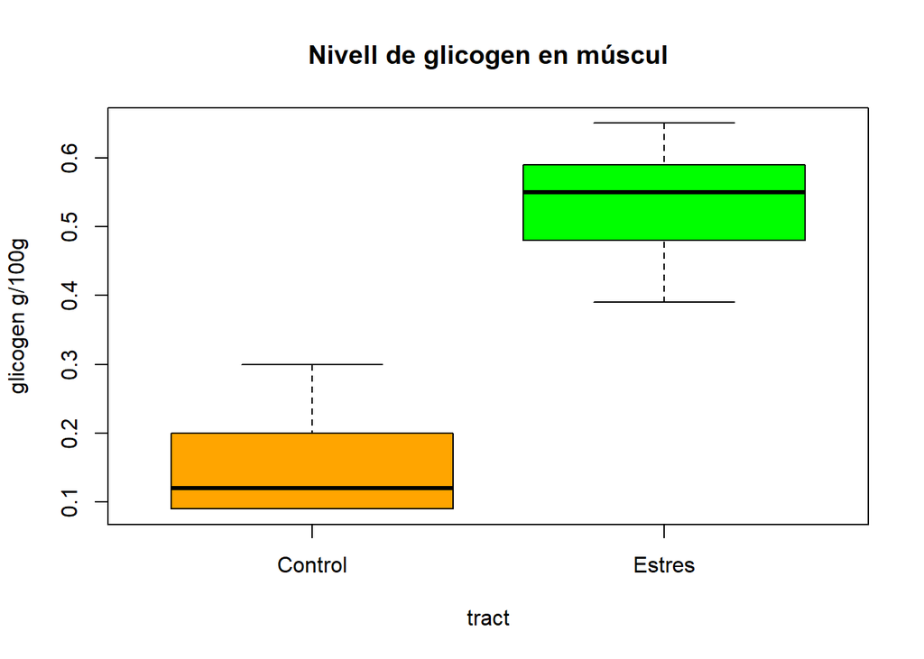

```r
gli<-c(0.55,0.61,0.49,0.59,0.65,0.39,0.48,0.59,0.41,0.11,0.20,0.09,0.12,0.09,0.09,0.22,0.30,0.20)
tract<-factor(rep(c('Estres','Control'),each=9))
gabia<-factor(rep(1:6,each=3))
glico<-data.frame(gli,tract,gabia)
boxplot(gli~tract,glico,col=c('orange','green'),main='Nivell de glicogen en múscul',ylab='glicogen g/100g')
```

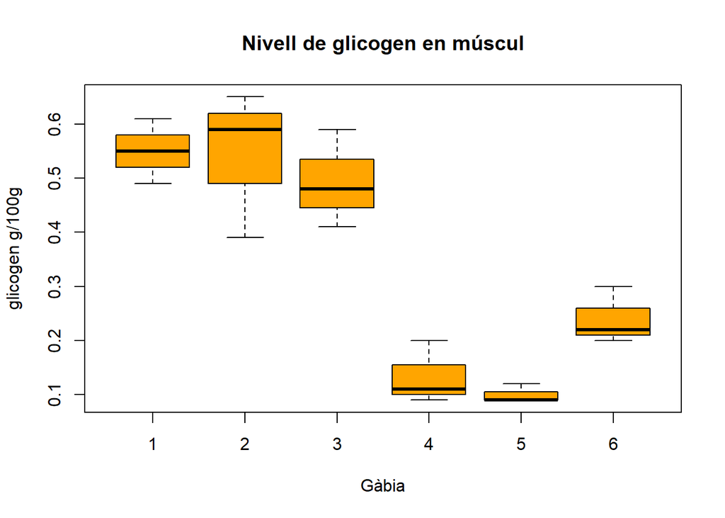

```r
boxplot(gli~gabia,glico,col='orange',main='Nivell de glicogen en múscul',xlab='Gàbia',ylab='glicogen g/100g')
```

## 1.3 Comentaris al disseny de l’Exemple 1

- El tractament és un factor fix.
- La gàbia és un factor bloc aleatori.
- Tenim 3 rèpliques per cada combinació de nivells dels dos factors.
- **És possible estudiar la interacció entre els dos factors?**
- El *fet diferencial* és que a diferència amb el disseny de dos factors creuats (un factor bloc) no totes les gàbies s’han estudiat sota les dues condicions: el factor gàbia està **jerarquitzat** (també anomenat **niat**) **al tractament**
- Esquemàticament, indiquem els dos factors: **Tractament** i **Gàbia(Tractament)** o en general (A, B(A))

## 1.4 Esquema general d’un disseny jerarquitzat de dos factors: A, B(A)

- Disseny multifactorial al qual els nivells d’un factor són similars però no idèntics per cada nivell d’un altre factor.
- Criteri: B jeràrquicament dins A si per cada nivell d’A podem canviar arbitràriament la numeració dels nivells de B:

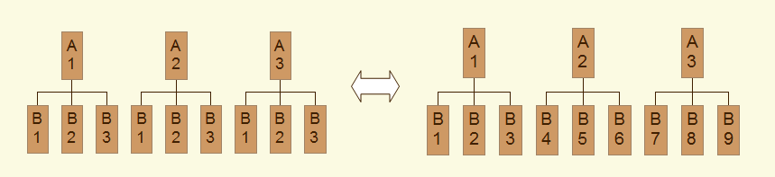

Què passaria si en el nostre exemple:

- Ignoréssim en el disseny la informació de la gàbia.
- L’experiment fes una barreja de rates amb estrès i sense dins de cada gàbia?

## 1.5 Codificació en R de l’exemple 1

Es requereixen tres variables:

1. La primera variable identifica el tractament.
2. La segona variable identifica la gàbia. **Podem optar per començar des de 1 a cada nivell del tractament o continuar la numeració des de 1 fins a 6**
3. La tercera és la variable resposta.

```r
gli<-c(0.55,0.61,0.49,0.59,0.65,0.39,0.48,0.59,0.41,0.11,0.20,0.09,0.12,0.09,0.09,0.22,0.30,0.20)
tract<-factor(rep(c('Estres','Control'),each=9))
gabia<-factor(rep(rep(1:3,each=3),2))
glico<-data.frame(gli,tract,gabia)
glico
```

| gli | tract | gabia |
| --- | --- | --- |
| 0.55 | Estres | 1 |
| 0.61 | Estres | 1 |
| 0.49 | Estres | 1 |
| 0.59 | Estres | 2 |
| 0.65 | Estres | 2 |
| 0.39 | Estres | 2 |
| 0.48 | Estres | 3 |
| 0.59 | Estres | 3 |
| 0.41 | Estres | 3 |
| 0.11 | Control | 1 |
| 0.20 | Control | 1 |
| 0.09 | Control | 1 |
| 0.12 | Control | 2 |
| 0.09 | Control | 2 |
| 0.09 | Control | 2 |
| 0.22 | Control | 3 |
| 0.30 | Control | 3 |
| 0.20 | Control | 3 |

## 1.6 Model estadístic d’un disseny jeràrquic amb dos factors fixos

El model és el següent:

$$Y_{ijk} = \mu +\alpha_i + \beta_{j(i)}
+ e_{k(ij)}$$

amb $i=1,...,a$, $j=1,...,b$, $k=1,...,r_{j(i)}$.

En aquest cas $\sum_{i=1}^a \alpha_i = 0$; $\sum_{j=1}^b \beta_{j(i)} = 0 \,\,\, i=1,...,a$; $e_{k(ij)} \sim N(0,\sigma)$.

- L’equació representa el cas totalment balancejat però hi pot haver manca de balanceig a qualsevol nivell jeràrquic.
- No hi han interaccions, no tenen sentit en no haver encreuament entre factors.

## 1.7 Model estadístic d’un disseny jeràrquic amb un factor fix (A) i un factor aleatori (B) niat

Es potser el més freqüent de tots. Usualment el factor niat és aleatori (un bloc) com en l’exemple 1, però en principi es pot presentar qualsevol de les quatre combinacions possibles fix-aleatori.

El model és el següent:

$$Y_{ijk} = \mu +\alpha_i + B_{j(i)} +
e_{k(ij)}$$

amb $i=1,...,a$, $j=1,...,b$, $k=1,...,r_{j(i)}$.

En aquest cas $\sum_{i=1}^a \alpha_i = 0$; $B_{j(i)} \sim N(0,\sigma_B)$; $e_{k(ij)} \sim N(0,\sigma)$.

## 1.8 Model amb els dos factors aleatoris

$$Y_{ijk} = \mu +A_i + B_{j(i)} +
e_{k(ij)}$$

amb $i=1,...,a$, $j=1,...,b$, $k=1,...,r_{j(i)}$.

En aquest cas $A_i \sim N(0,\sigma_A)$; $B_{j(i)} \sim N(0,\sigma_B)$; $e_{k(ij)} \sim N(0,\sigma)$.

- En tots els casos assumim independència entre les variables aleatòries dels models amb factors aleatoris.
- És molt estrany un model amb el factor principal aleatori i el factor niat fix.

## 1.9 Descomposició de la variabilitat

- Aquesta descomposició és comú a tots els models anteriors (fixos, aleatoris, mixt).
- Assumim un disseny totalment balancejat amb $r_{j(i)}=n$.

$$\begin{array}{ccl}
SS_T & = & \sum_{i=1}^{a} \sum_{j=1}^{b} \sum_{k=1}^{n}
(Y_{ijk}-\overline{Y}_{...} )^2 = \\[10pt]
& = & bn \sum_{i=1}^{a} (\overline{Y}_{i..}-\overline{Y}_{...}
)^2 + n \sum_{i=1}^{a}
\sum_{j=1}^{b} (\overline{Y}_{ij.}-\overline{Y}_{i..})^2 +
\sum_{i=1}^{a} \sum_{j=1}^{b} \sum_{k=1}^{n} (Y_{ijk}-\overline{Y}_{ij.}
)^2 = \\[10pt]
& = & SS_A + SS_{B(A)} + SS_E
\end{array}$$

on

- $SS_T$ recull la variabilitat total de les dades,
- $SS_A$ recull la variabilitat deguda al factor A
- $SS_{B(A)}$ recull la variabilitat deguda al factor B niat en el factor A
- $SS_E$ recull la variabilitat residual

## 1.10 Esperances dels quadrats mitjans

$$\begin{array}{c|ccc}
E(MS) & \mbox{A fix - B fix} & \mbox{A fix - B aleatori} &
\mbox{A aleatori - B aleatori} \\ \hline
E(MS_A) & \sigma^2 + \frac{ bn \sum_{i=1}^a \alpha_i^2}{a-1} &
\sigma^2 + n \sigma^2_B + \frac{ bn \sum_{i=1}^a \alpha_i^2}{a-1} &
\sigma^2 + n \sigma^2_B + bn \sigma_A^2 \\
E(MS_{B(A)}) & \sigma^2 + \frac{ \sum_{i=1}^a \sum_{j=1}^b
\beta_{j(i)}^2}{a(b-1)} & \sigma^2 + n \sigma^2_B & \sigma^2 +
n \sigma^2_B \\
E(MS_E) & \sigma^2 & \sigma^2 & \sigma^2 \\ \hline
\end{array}$$

## 1.11 Taules ANOVA d’un disseny jeràrquic de dos factors

### 1.11.1 A fix, B fix

$$\begin{array}{ccc}
\mbox{Factor} & \mbox{Estadístic F} & \mbox{graus de llibertat}
\\ \hline
\begin{array}{c}
\mbox{Factor A} \\ H_0: \alpha_1 = \ldots = \alpha_a =0 \end{array}
& \frac{MS_A}{MS_E} & F(a-1,ab(n-1)) \\ \hline
\begin{array}{c}
\mbox{Factor B} \\ H_0: \beta_{1(1)} = \beta_{2(1)} = \ldots =
\beta_{j(i)} =0 \end{array} & \frac{MS_{B(A)}}{MS_E} &
F(a(b-1),ab(n-1)) \\ \hline
\end{array}$$

### 1.11.2 A fix, B aleatori

$$\begin{array}{ccc}
\mbox{Factor} & \mbox{Estadístic F} & \mbox{graus de llibertat}
\\ \hline
\begin{array}{c}
\mbox{Factor A} \\ H_0: \alpha_1 = \ldots = \alpha_a =0 \end{array}
& \frac{MS_A}{MS_{B(A)}} & F(a-1,a(b-1)) \\ \hline
\begin{array}{c}
\mbox{Factor B} \\ H_0: \sigma^2_B =0 \end{array} &
\frac{MS_{B(A)}}{MS_E} & F(a(b-1),ab(n-1)) \\ \hline
\end{array}$$

### 1.11.3 A aleatori, B aleatori

$$\begin{array}{ccc}
\mbox{Factor} & \mbox{Estadístic F} & \mbox{graus de llibertat}
\\ \hline
\begin{array}{c}
\mbox{Factor A} \\ H_0: \sigma^2_A =0 \end{array} &
\frac{MS_A}{MS_{B(A)}} & F(a-1,a(b-1)) \\ \hline
\begin{array}{c}
\mbox{Factor B} \\ H_0: \sigma^2_B =0 \end{array} &
\frac{MS_{B(A)}}{MS_E} & F(a(b-1),ab(n-1)) \\ \hline
\end{array}$$

## 1.12 Estimació de paràmetres

### 1.12.1 Estimadors puntuals dels paràmetres del model

- $\hat{\mu} = \overline{Y}_{...}$
- $\hat{\alpha_i} = \overline{Y}_{i..} - \overline{Y}_{...} \,\,\,\, (\alpha_i = \mu_i - \mu)$
- $\hat{\beta_{j(i)}} = \overline{Y}_{ij.} - \overline{Y}_{i..}$

### 1.12.2 Valor predit i residu

- $\hat{Y_{ijk}} = \overline{Y_{ij.}}$
- $\hat{e_{k(ij)}} = Y_{ijk} - \overline{Y_{ij.}}$

### 1.12.3 Components de la variància

- $\hat{\sigma^2} =MS_E$
- $\hat{\sigma_B^2} = \frac{MS_{B(A)}-MS_E}{n}$
- $\hat{\sigma_A^2} = \frac{MS_A-MS_{B(A)}}{bn}$

## 1.13 Resolució amb R de l’exemple 1

### 1.13.1 Resolució amb aov

En aquest exemple considerem que el **tractament** és un factor fix i la **gàbia** un factor aleatori.

```r
glico
```

| gli | tract | gabia |
| --- | --- | --- |
| 0.55 | Estres | 1 |
| 0.61 | Estres | 1 |
| 0.49 | Estres | 1 |
| 0.59 | Estres | 2 |
| 0.65 | Estres | 2 |
| 0.39 | Estres | 2 |
| 0.48 | Estres | 3 |
| 0.59 | Estres | 3 |
| 0.41 | Estres | 3 |
| 0.11 | Control | 1 |
| 0.20 | Control | 1 |
| 0.09 | Control | 1 |
| 0.12 | Control | 2 |
| 0.09 | Control | 2 |
| 0.09 | Control | 2 |
| 0.22 | Control | 3 |
| 0.30 | Control | 3 |
| 0.20 | Control | 3 |

```r
glico.aov<-aov(gli~tract+gabia %in% tract, glico)
anova(glico.aov) # De moment la taula ANOVA és incorrecta, assumeix factors fixos
```

|  | Df | Sum Sq | Mean Sq | F value | Pr(>F) |
| --- | --- | --- | --- | --- | --- |
| tract | 1 | 0.6197556 | 0.6197556 | 100.773261 | 0.0000003 |
| tract:gabia | 4 | 0.0378444 | 0.0094611 | 1.538392 | 0.2531091 |
| Residuals | 12 | 0.0738000 | 0.0061500 | NA | NA |

- Obtenció manual de la taula correcta

```r
taula<-anova(glico.aov)
taula[1,4]<-taula[1,3]/taula[2,3]
taula[1,5]<-1-pf(taula[1,4],taula[1,1],taula[2,1])
taula
```

|  | Df | Sum Sq | Mean Sq | F value | Pr(>F) |
| --- | --- | --- | --- | --- | --- |
| tract | 1 | 0.6197556 | 0.6197556 | 65.505578 | 0.0012666 |
| tract:gabia | 4 | 0.0378444 | 0.0094611 | 1.538392 | 0.2531091 |
| Residuals | 12 | 0.0738000 | 0.0061500 | NA | NA |

- Estimació de paràmetres

```r
mean(glico$gli) # mu
```

```
## [1] 0.3433333
```

```r
model.tables(glico.aov,type='means')$tables$tract # alpha_i
```

```
## tract
##   Control    Estres
## 0.1577778 0.5288889
```

```r
(taula[2,3]-taula[3,3])/3  # sigma_B^2
```

```
## [1] 0.001103704
```

```r
taula[3,3]  # sigma^2
```

```
## [1] 0.00615
```

- Comparacions múltiples (en aquest exemple no serien necessàries donat que només tenim dos nivells del factor fix)

```r
library(agricolae)
HSD.test(glico$gli,glico$tract,DFerror=taula[2,1],MSerror=taula[2,3],console=T,group=F)
```

```
##
## Study: glico$gli ~ glico$tract
##
## HSD Test for glico$gli
##
## Mean Square Error:  0.009461111
##
## glico$tract,  means
##
##         glico.gli        std r         se  Min  Max  Q25  Q50  Q75
## Control 0.1577778 0.07512952 9 0.03242275 0.09 0.30 0.09 0.12 0.20
## Estres  0.5288889 0.09116530 9 0.03242275 0.39 0.65 0.48 0.55 0.59
##
## Alpha: 0.05 ; DF Error: 4
## Critical Value of Studentized Range: 3.926503
##
## Comparison between treatments means
##
##                  difference pvalue signif.        LCL        UCL
## Control - Estres -0.3711111 0.0013      ** -0.4984191 -0.2438031
```

Noteu que fem servir el terme d’error correcte i no la versió per defecte

```r
HSD.test(glico.aov,'tract',console=T,group=F)
```

[output not shown]

#### 1.13.1.1 Resolució alternativa en cas de disseny balancejat

**Si tenim el mateix número de rèpliques a cada nivell del factor niat** és possible fer l’anàlisi agregant les dades en cada nivell del factor niat (calculant el promig de les observacions dintre de cada nivell) i fer un ANOVA d’un factor comparant els nivells del factor al capdamunt de la jerarquia. El resultat del test serà equivalent.

```r
gabia<-gl(6,3)
promig<-aggregate(glico$gli,list(gabia),mean)
tract<-as.factor(rep(c('Estres','Control'),each=3))
dades<-data.frame(tract,gli=promig$x)
dades.aov<-aov(gli~tract,dades)
anova(dades.aov)
```

|  | Df | Sum Sq | Mean Sq | F value | Pr(>F) |
| --- | --- | --- | --- | --- | --- |
| tract | 1 | 0.2065852 | 0.2065852 | 65.50558 | 0.0012666 |
| Residuals | 4 | 0.0126148 | 0.0031537 | NA | NA |

```r
HSD.test(dades.aov,'tract',console=T,group=F)
```

```
##
## Study: dades.aov ~ "tract"
##
## HSD Test for gli
##
## Mean Square Error:  0.003153704
##
## tract,  means
##
##               gli        std r         se       Min  Max       Q25       Q50
## Control 0.1577778 0.07313103 3 0.03242275 0.1000000 0.24 0.1166667 0.1333333
## Estres  0.5288889 0.03097191 3 0.03242275 0.4933333 0.55 0.5183333 0.5433333
##               Q75
## Control 0.1866667
## Estres  0.5466667
##
## Alpha: 0.05 ; DF Error: 4
## Critical Value of Studentized Range: 3.926503
##
## Comparison between treatments means
##
##                  difference pvalue signif.        LCL        UCL
## Control - Estres -0.3711111 0.0013      ** -0.4984191 -0.2438031
```

### 1.13.2 Resolució amb el package *mixlm*

```r
library(mixlm)
glico.aov<-lm(gli~tract+r(gabia) %in% tract, glico)
Anova(glico.aov,type='III')
```

```
## Analysis of variance (unrestricted model)
## Response: gli
##             Mean Sq Sum Sq Df F value Pr(>F)
## tract         0.620   0.62  1   65.51 0.0013
## tract:gabia   0.009   0.04  4    1.54 0.2531
## Residuals     0.006   0.07 12       -      -
##
##               Err.term(s) Err.df  VC(SS)
## 1 tract               (2)      4   fixed
## 2 tract:gabia         (3)     12 0.00110
## 3 Residuals             -      - 0.00615
## (VC = variance component)
##
##             Expected mean squares
## tract        (3) + 3 (2) + 9 Q[1]
## tract:gabia  (3) + 3 (2)
## Residuals    (3)
```

### 1.13.3 Resolució amb lmer(lme4) (Opcional)

Primer hem de crear un factor gàbia inequívocament determinat, **aquí es obligatoria indicar les gàbies des de 1 fins a 6**

```r
gli<-c(0.55,0.61,0.49,0.59,0.65,0.39,0.48,0.59,0.41,0.11,0.20,0.09,0.12,0.09,0.09,0.22,0.30,0.20)
tract<-factor(rep(c('Estres','Control'),each=9))
gabia<-factor(rep(1:6,each=3))
glico<-data.frame(gli,tract,gabia)
glico
```

| gli | tract | gabia |
| --- | --- | --- |
| 0.55 | Estres | 1 |
| 0.61 | Estres | 1 |
| 0.49 | Estres | 1 |
| 0.59 | Estres | 2 |
| 0.65 | Estres | 2 |
| 0.39 | Estres | 2 |
| 0.48 | Estres | 3 |
| 0.59 | Estres | 3 |
| 0.41 | Estres | 3 |
| 0.11 | Control | 4 |
| 0.20 | Control | 4 |
| 0.09 | Control | 4 |
| 0.12 | Control | 5 |
| 0.09 | Control | 5 |
| 0.09 | Control | 5 |
| 0.22 | Control | 6 |
| 0.30 | Control | 6 |
| 0.20 | Control | 6 |

Després ajustem el model

```r
library(lme4)
library(lmerTest)
glico.lmer<-lmer(gli~tract+(1|gabia),glico)
summary(glico.lmer)
```

```
## Linear mixed model fit by REML. t-tests use Satterthwaite's method [
## lmerModLmerTest]
## Formula: gli ~ tract + (1 | gabia)
##    Data: glico
##
## REML criterion at convergence: -29.9
##
## Scaled residuals:
##      Min       1Q   Median       3Q      Max
## -1.83551 -0.60235 -0.02621  0.69797  1.47989
##
## Random effects:
##  Groups   Name        Variance Std.Dev.
##  gabia    (Intercept) 0.001104 0.03322
##  Residual             0.006150 0.07842
## Number of obs: 18, groups:  gabia, 6
##
## Fixed effects:
##             Estimate Std. Error      df t value Pr(>|t|)
## (Intercept)  0.15778    0.03242 4.00000   4.866  0.00824 **
## tractEstres  0.37111    0.04585 4.00000   8.094  0.00127 **
## ---
## Signif. codes:  0 '***' 0.001 '**' 0.01 '*' 0.05 '.' 0.1 ' ' 1
##
## Correlation of Fixed Effects:
##             (Intr)
## tractEstres -0.707
```

```r
anova(glico.lmer)
```

|  | Sum Sq | Mean Sq | NumDF | DenDF | F value | Pr(>F) |
| --- | --- | --- | --- | --- | --- | --- |
| tract | 0.4028593 | 0.4028593 | 1 | 4 | 65.50558 | 0.0012666 |

```r
confint(glico.lmer)
```

```
##                  2.5 %     97.5 %
## .sig01      0.00000000 0.08054617
## .sigma      0.05508974 0.11360729
## (Intercept) 0.09636518 0.21919040
## tractEstres 0.28426058 0.45796167
```

```r
ranova(glico.lmer)
```

|  | npar | logLik | AIC | LRT | Df | Pr(>Chisq) |
| --- | --- | --- | --- | --- | --- | --- |
|  | 4 | 14.96871 | -21.93742 | NA | NA | NA |
| (1 \| gabia) | 3 | 14.12681 | -22.25362 | 1.683798 | 1 | 0.1944206 |

```r
fixef(glico.lmer)
```

```
## (Intercept) tractEstres
##   0.1577778   0.3711111
```

```r
ranef(glico.lmer)
```

```
## $gabia
##    (Intercept)
## 1  0.007388269
## 2  0.005055131
## 3 -0.012443400
## 4 -0.008554837
## 5 -0.020220525
## 6  0.028775362
##
## with conditional variances for "gabia"
```

## 1.14 Models jeràrquics amb tres factors

En haver tres o més factors es poden donar diferents combinacions de factors creuats i niats. En dissenys de tres factors, que de forma genèrica anomenarem A, B i C, podem tenir els següents dissenys:

1. A i B completament creuats, C niat dins A, creuat respecte a B: el model es denota com A, B, C(A).
2. A i B completament creuats, C niat dins la interacció A x B: el model es denota A, B, C(AxB).
3. B niat dins de A, C niat dins de B: el model es denota A, B(A), C(B(A)) (niat pur)

### 1.14.1 Exemple 2.1

Un laboratori analític desitja comparar la sensibilitat de 3 reactius. També desitja comparar l’efecte de 2 temperatures de conservació: 7ºC i 20 ºC.

– **De cada reactiu es prenen mostres de 2 lots escollits a l’atzar** del total de lots subministrats pels proveïdors. Per tant, 6 lots en total.

– Per cada reactiu es prenen 6 mostres de cada lot (36 mostres en total analitzades). Es mesura la sensibilitat de cada mostra de reactiu . Un valor més alt de la resposta indica per tant un millor resultat.

– **Les mostres de cada lot es divideixen aleatòriament en 2 grups**, cadascun dels grups es conserva a una de les 2 temperatures.

– Les dades es troben al fitxer **dades/Exemple_2.1.csv**

```r
sensi1 <- read.table('../dades/Exemple_2.1.csv',sep=";",header=TRUE, dec=",", na.strings=' ',stringsAsFactors = T)
for (i in 1:3) sensi1[,i]<-as.factor(sensi1[,i])
head(sensi1,18)
```

| reactiu | lot | temperatura | resposta |
| --- | --- | --- | --- |
| 1 | 1 | 1 | 1.29 |
| 1 | 1 | 1 | 1.35 |
| 1 | 1 | 1 | 1.51 |
| 1 | 2 | 1 | 1.54 |
| 1 | 2 | 1 | 1.41 |
| 1 | 2 | 1 | 1.48 |
| 1 | 1 | 2 | 3.97 |
| 1 | 1 | 2 | 4.13 |
| 1 | 1 | 2 | 3.95 |
| 1 | 2 | 2 | 3.89 |
| 1 | 2 | 2 | 3.90 |
| 1 | 2 | 2 | 4.11 |
| 2 | 1 | 1 | 2.38 |
| 2 | 1 | 1 | 2.47 |
| 2 | 1 | 1 | 2.32 |
| 2 | 2 | 1 | 2.30 |
| 2 | 2 | 1 | 2.48 |
| 2 | 2 | 1 | 2.52 |

### 1.14.2 Exemple 2.2

Considerem una modificació de l’experiment anterior. Com en l’experiment original es desitja comparar la sensibilitat de 3 reactius.

– Cada reactiu es subministra en dos tipus de solucions: diluït al 10% i diluït al 20%, idèntiques per a cada reactiu.

– **De cada reactiu i tipus de solució es prenen mostres de 2 lots escollits a l’atzar** del total de lots subministrats pels proveïdors. Per tant, 12 lots en total.

– Per cada reactiu, solució i lot es prenen 3 mostres de cada lot (36 mostres en total analitzades) i es mesura la sensibilitat. Un valor més alt de la resposta indica per tant un millor resultat.

– Les dades es troben al fitxer **dades/Exemple_2.2.csv**

```r
sensi2 <- read.table('../dades/Exemple_2.2.csv',sep=";",header=TRUE, dec=",", na.strings=' ',stringsAsFactors = T)
for (i in 1:3) sensi2[,i]<-as.factor(sensi2[,i])
head(sensi2,18)
```

| reactiu | dilucio | lot | resposta |
| --- | --- | --- | --- |
| 1 | 10 | 1 | 1.29 |
| 1 | 10 | 1 | 1.35 |
| 1 | 10 | 1 | 1.51 |
| 1 | 10 | 2 | 1.54 |
| 1 | 10 | 2 | 1.41 |
| 1 | 10 | 2 | 1.48 |
| 1 | 20 | 1 | 3.97 |
| 1 | 20 | 1 | 4.13 |
| 1 | 20 | 1 | 3.95 |
| 1 | 20 | 2 | 3.89 |
| 1 | 20 | 2 | 3.90 |
| 1 | 20 | 2 | 4.11 |
| 2 | 10 | 1 | 2.38 |
| 2 | 10 | 1 | 2.47 |
| 2 | 10 | 1 | 2.32 |
| 2 | 10 | 2 | 2.30 |
| 2 | 10 | 2 | 2.48 |
| 2 | 10 | 2 | 2.52 |

### 1.14.3 Exemple 2.3

Suposem que l’experiment original es planteja ara de la següent manera. Com en l’experiment original es desitja comparar la sensibilitat de 3 reactius

– Cada reactiu es subministra en dos tipus de preparacions, **diferents per a cada reactiu**.

– De cada reactiu i tipus de preparació es prenen mostres de 2 lots escollits a l’atzar del total de lots subministrats pels proveïdors. Per tant, **12 lots en total**

– Per cada reactiu, solució i lot es prenen 3 mostres de cada lot (36 mostres en total analitzades) i es mesura la sensibilitat. Un valor més alt de la resposta indica per tant un millor resultat.

– Les dades es troben al fitxer **dades/Exemple_2.3.csv**

```r
sensi3 <- read.table('../dades/Exemple_2.3.csv',sep=";",header=TRUE, dec=",", na.strings=' ',stringsAsFactors = T)
for (i in 1:3) sensi3[,i]<-as.factor(sensi3[,i])
head(sensi3,18)
```

| reactiu | preparacio | lot | resposta |
| --- | --- | --- | --- |
| 1 | 1 | 1 | 1.29 |
| 1 | 1 | 1 | 1.35 |
| 1 | 1 | 1 | 1.51 |
| 1 | 1 | 2 | 1.54 |
| 1 | 1 | 2 | 1.41 |
| 1 | 1 | 2 | 1.48 |
| 1 | 2 | 1 | 3.97 |
| 1 | 2 | 1 | 4.13 |
| 1 | 2 | 1 | 3.95 |
| 1 | 2 | 2 | 3.89 |
| 1 | 2 | 2 | 3.90 |
| 1 | 2 | 2 | 4.11 |
| 2 | 1 | 1 | 2.38 |
| 2 | 1 | 1 | 2.47 |
| 2 | 1 | 1 | 2.32 |
| 2 | 1 | 2 | 2.30 |
| 2 | 1 | 2 | 2.48 |
| 2 | 1 | 2 | 2.52 |

## 1.15 Models estadístics jeràrquics amb tres factors. Model A, B, C(A) (Exemple 2.1)

El model és el següent:

$$Y_{ijkl} = \mu +\alpha_i + \beta_j
+(\alpha \beta)_{ij}+ C_{k(i)} + (\beta C)_{jk(i)} + e_{ijkl}$$

amb $i=1,...,a$; $j=1,...,b$; $k=1,...,c$; $l=1,...,n$.

En aquest cas $\sum_{i=1}^a \alpha_i = 0$; $\sum_{j=1}^b \beta_j = 0$; $\sum_{i=1}^a (\alpha \beta)_{ij} = 0 \,\, j=1,...,b$; $\sum_{j=1}^b (\alpha \beta)_{ij} = 0 \,\, i=1,...,a$; $C_{k(i)} \sim N(0,\sigma_C)$; $(\beta C)_{jk(i)} \sim N(0,\sigma_{(\beta C)})$;$e_{ijkl} \sim N(0,\sigma)$.

### 1.15.1 Taula ANOVA

| Font de variació | Suma de quadrats | Graus de llibertat | Quadrats mitjans | Estadístic F |
| --- | --- | --- | --- | --- |
| Factor A (fix) | $SS_A$ | $a-1$ | $MS_A = \frac{SS_A}{a-1}$ | $F = \frac{MS_A}{MS_{C(A)}}$ |
| Factor B (fix) | $SS_B$ | $b-1$ | $MS_B = \frac{SS_B}{b-1}$ | $F = \frac{MS_B}{MS_{BC(A)}}$ |
| Factor C(A) (aleat) | $SS_{C(A)}$ | $a(c-1)$ | $MS_{C(A)} = \frac{SS_{C(A)}}{a(c-1)}$ | $F = \frac{MS_{C(A)}}{MS_E}$ |
| Interacció AB | $SS_{AB}$ | $(a-1)(b-1)$ | $MS_{AB} = \frac{SS_{AB}}{(a-1)(b-1)}$ | $F = \frac{MS_{AB}}{MS_{BC(A)}}$ |
| Interacció BC(A) | $SS_{BC(A)}$ | $a(b-1)(c-1)$ | $MS_{BC(A)} = \frac{SS_{BC(A)}}{a(b-1)(c-1)}$ | $F = \frac{MS_{BC(A)}}{MS_E}$ |
| Error | $SS_E$ | $N-abc$ | $MS_E = \frac{SS_E}{N-abc}$ |  |
| Total | $SS_T$ | $N-1$ |  |  |

### 1.15.2 Model simplificat

És molt freqüent treballar amb un model simplificat que no considera la interacció $(\beta C)_{jk(i)}$.

$$Y_{ijkl} = \mu +\alpha_i + \beta_j
+(\alpha \beta)_{ij}+ C_{k(i)} + e_{ijkl}$$

En aquest cas la taula ANOVA és

| Font de variació | Suma de quadrats | Graus de llibertat | Quadrats mitjans | Estadístic F |
| --- | --- | --- | --- | --- |
| Factor A (fix) | $SS_A$ | $a-1$ | $MS_A = \frac{SS_A}{a-1}$ | $F = \frac{MS_A}{MS_{C(A)}}$ |
| Factor B (fix) | $SS_B$ | $b-1$ | $MS_B = \frac{SS_B}{b-1}$ | $F = \frac{MS_B}{MS_E}$ |
| Factor C(A) (aleat) | $SS_{C(A)}$ | $a(c-1)$ | $MS_{C(A)} = \frac{SS_{C(A)}}{a(c-1)}$ | $F = \frac{MS_{C(A)}}{MS_E}$ |
| Interacció AB | $SS_{AB}$ | $(a-1)(b-1)$ | $MS_{AB} = \frac{SS_{AB}}{(a-1)(b-1)}$ | $F = \frac{MS_{AB}}{MS_E}$ |
| Error | $SS_E$ | $N-a(b+c-1)$ | $MS_E = \frac{SS_E}{N-a(b+c-1)}$ |  |
| Total | $SS_T$ | $N-1$ |  |  |

## 1.16 Model A, B, C(AxB) (Exemple 2.2)

El model és el següent:

$$Y_{ijkl} = \mu +\alpha_i + \beta_j
+(\alpha \beta)_{ij}+ C_{k(ij)} + e_{ijkl}$$

amb $i=1,...,a$; $j=1,...,b$; $k=1,...,c$; $l=1,...,n$.

En aquest cas $\sum_{i=1}^a \alpha_i = 0$; $\sum_{j=1}^b \beta_j = 0$; $\sum_{i=1}^a (\alpha \beta)_{ij} = 0 \,\, j=1,...,b$; $\sum_{j=1}^b (\alpha \beta)_{ij} = 0 \,\, i=1,...,a$; $C_{k(ij)} \sim N(0,\sigma_C)$; $e_{ijkl} \sim N(0,\sigma)$.

### 1.16.1 Taula ANOVA

| Font de variació | Suma de quadrats | Graus de llibertat | Quadrats mitjans | Estadístic F |
| --- | --- | --- | --- | --- |
| Factor A (fix) | $SS_A$ | $a-1$ | $MS_A = \frac{SS_A}{a-1}$ | $F = \frac{MS_A}{MS_{C(AB)}}$ |
| Factor B (fix) | $SS_B$ | $b-1$ | $MS_B = \frac{SS_B}{b-1}$ | $F = \frac{MS_B}{MS_{C(AB)}}$ |
| Factor C(AB) (aleat) | $SS_{C(AB)}$ | $ab(c-1)$ | $MS_{C(AB)} = \frac{SS_{C(AB)}}{ab(c-1)}$ | $F = \frac{MS_{C(AB)}}{MS_E}$ |
| Interacció AB | $SS_{AB}$ | $(a-1)(b-1)$ | $MS_{AB} = \frac{SS_{AB}}{(a-1)(b-1)}$ | $F = \frac{MS_{AB}}{MS_{C(AB)}}$ |
| Error | $SS_E$ | $N-abc$ | $MS_E = \frac{SS_E}{N-abc}$ |  |
| Total | $SS_T$ | $N-1$ |  |  |

## 1.17 Model A, B(A), C(B(A)) (Exemple 2.3)

El model és el següent:

$$Y_{ijkl} = \mu +\alpha_i + \beta_{j(i)}
+ C_{k(j(i))} + e_{ijkl}$$

amb $i=1,...,a$; $j=1,...,b$; $k=1,...,c$; $l=1,...,n$.

En aquest cas $\sum_{i=1}^a \alpha_i = 0$; $\sum_{j=1}^b \beta_{j(i)} = 0 \,\,\, i=1,...,a$; $C_{k(j(i))} \sim N(0,\sigma_C)$; $e_{ijkl} \sim N(0,\sigma)$.

### 1.17.1 Taula ANOVA

| Font de variació | Suma de quadrats | Graus de llibertat | Quadrats mitjans | Estadístic F |
| --- | --- | --- | --- | --- |
| Factor A (fix) | $SS_A$ | $a-1$ | $MS_A = \frac{SS_A}{a-1}$ | $F = \frac{MS_A}{MS_{C(B(A))}}$ |
| Factor B(A) (fix) | $SS_{B(A)}$ | $a(b-1)$ | $MS_{B(A)} = \frac{SS_{B(A)}}{a(b-1)}$ | $F = \frac{MS_{B(A)}}{MS_{C(B(A))}}$ |
| Factor C(B(A)) (aleat) | $SS_{C(B(A))}$ | $ab(c-1)$ | $MS_{C(B(A))} = \frac{SS_{C(B(A))}}{ab(c-1)}$ | $F = \frac{MS_{C(B(A))}}{MS_E}$ |
| Error | $SS_E$ | $abc(n-1)$ | $MS_E = \frac{SS_E}{abc(n-1)}$ |  |
| Total | $SS_T$ | $N-1$ |  |  |

- Nota: si B i C són aleatoris o tots tres fossin aleatoris, la taula seria $F_A = \frac{MS_A}{MS_{B(A)}}$, $F_B = \frac{MS_{B(A)}}{MS_{C(B(A))}}$ i $F_C = \frac{MS_{C(B(A))}}{MS_E}$.

## 1.18 Resolució amb R de l’exemple 2.1

### 1.18.1 Model complet

```r
sensi1.aov <- aov(resposta ~ reactiu * temperatura + lot %in% reactiu + (lot %in% reactiu):temperatura, sensi1)

taula<-anova(sensi1.aov)
taula[1,4]<-taula[1,3]/taula[4,3] # Modificació F factor fix A
taula[1,5]<-1-pf(taula[1,4],taula[1,1],taula[4,1])
taula[2,4]<-taula[2,3]/taula[5,3] # Modificació F factor fix B
taula[2,5]<-1-pf(taula[2,4],taula[2,1],taula[5,1])
taula[3,4]<-taula[3,3]/taula[5,3] # Modificació F interacció AB
taula[3,5]<-1-pf(taula[3,4],taula[3,1],taula[5,1])
taula
```

|  | Df | Sum Sq | Mean Sq | F value | Pr(>F) |
| --- | --- | --- | --- | --- | --- |
| reactiu | 2 | 4.5420389 | 2.2710194 | 85.9691903 | 0.0022457 |
| temperatura | 1 | 28.0900000 | 28.0900000 | 3640.1727862 | 0.0000100 |
| reactiu:temperatura | 2 | 6.9526500 | 3.4763250 | 450.4956803 | 0.0001912 |
| reactiu:lot | 3 | 0.0792500 | 0.0264167 | 2.1342011 | 0.1223242 |
| reactiu:temperatura:lot | 3 | 0.0231500 | 0.0077167 | 0.6234291 | 0.6067788 |
| Residuals | 24 | 0.2970667 | 0.0123778 | NA | NA |

### 1.18.2 Model simplificat

```r
sensi1s.aov <- aov(resposta ~ reactiu * temperatura + lot %in% reactiu , sensi1)

taula<-anova(sensi1s.aov)
taula[1,4]<-taula[1,3]/taula[4,3] # Modificació F factor fix A
taula[1,5]<-1-pf(taula[1,4],taula[1,1],taula[4,1])
taula
```

|  | Df | Sum Sq | Mean Sq | F value | Pr(>F) |
| --- | --- | --- | --- | --- | --- |
| reactiu | 2 | 4.5420389 | 2.2710194 | 85.969190 | 0.0022457 |
| temperatura | 1 | 28.0900000 | 28.0900000 | 2368.490085 | 0.0000000 |
| reactiu:temperatura | 2 | 6.9526500 | 3.4763250 | 293.116458 | 0.0000000 |
| reactiu:lot | 3 | 0.0792500 | 0.0264167 | 2.227398 | 0.1079031 |
| Residuals | 27 | 0.3202167 | 0.0118599 | NA | NA |

### 1.18.3 Ajust amb lmer del model simplificat (OPCIONAL)

```r
sensi1$lot2<-as.factor(c(1,1,1,2,2,2,1,1,1,2,2,2,3,3,3,4,4,4,3,3,3,4,4,4,5,5,5,6,6,6,5,5,5,6,6,6))
sensi1.lmer<-lmer(resposta ~ reactiu * temperatura+(1|lot2),sensi1)
summary(sensi1.lmer)
```

```
## Linear mixed model fit by REML. t-tests use Satterthwaite's method [
## lmerModLmerTest]
## Formula: resposta ~ reactiu * temperatura + (1 | lot2)
##    Data: sensi1
##
## REML criterion at convergence: -34.7
##
## Scaled residuals:
##     Min      1Q  Median      3Q     Max
## -1.2307 -0.6568 -0.2831  0.7446  2.1821
##
## Random effects:
##  Groups   Name        Variance Std.Dev.
##  lot2     (Intercept) 0.002426 0.04926
##  Residual             0.011860 0.10890
## Number of obs: 36, groups:  lot2, 6
##
## Fixed effects:
##                       Estimate Std. Error       df t value Pr(>|t|)
## (Intercept)            1.43000    0.05648  6.16044  25.320 1.84e-07 ***
## reactiu2               0.98167    0.07987  6.16044  12.291 1.45e-05 ***
## reactiu3               1.11167    0.07987  6.16044  13.918 6.92e-06 ***
## temperatura2           2.56167    0.06288 27.00000  40.742  < 2e-16 ***
## reactiu2:temperatura2 -0.36500    0.08892 27.00000  -4.105 0.000335 ***
## reactiu3:temperatura2 -2.02000    0.08892 27.00000 -22.717  < 2e-16 ***
## ---
## Signif. codes:  0 '***' 0.001 '**' 0.01 '*' 0.05 '.' 0.1 ' ' 1
##
## Correlation of Fixed Effects:
##             (Intr) react2 react3 tmprt2 rct2:2
## reactiu2    -0.707
## reactiu3    -0.707  0.500
## temperatur2 -0.557  0.394  0.394
## rct2:tmprt2  0.394 -0.557 -0.278 -0.707
## rct3:tmprt2  0.394 -0.278 -0.557 -0.707  0.500
```

```r
anova(sensi1.lmer)
```

|  | Sum Sq | Mean Sq | NumDF | DenDF | F value | Pr(>F) |
| --- | --- | --- | --- | --- | --- | --- |
| reactiu | 2.039168 | 1.019584 | 2 | 3 | 85.96919 | 0.0022457 |
| temperatura | 28.090003 | 28.090003 | 1 | 27 | 2368.49030 | 0.0000000 |
| reactiu:temperatura | 6.952650 | 3.476325 | 2 | 27 | 293.11646 | 0.0000000 |

```r
ranova(sensi1.lmer)
```

|  | npar | logLik | AIC | LRT | Df | Pr(>Chisq) |
| --- | --- | --- | --- | --- | --- | --- |
|  | 8 | 17.37423 | -18.74846 | NA | NA | NA |
| (1 \| lot2) | 7 | 12.56223 | -11.12447 | 9.623989 | 1 | 0.0019205 |

```r
ranef(sensi1.lmer)
```

```
## $lot2
##    (Intercept)
## 1 -0.005969662
## 2  0.005969662
## 3 -0.021123418
## 4  0.021123418
## 5 -0.039032403
## 6  0.039032403
##
## with conditional variances for "lot2"
```

```r
fixef(sensi1.lmer)
```

```
##           (Intercept)              reactiu2              reactiu3
##             1.4300000             0.9816667             1.1116667
##          temperatura2 reactiu2:temperatura2 reactiu3:temperatura2
##             2.5616667            -0.3650000            -2.0200000
```

## 1.19 Resolució amb R de l’exemple 2.2

```r
sensi2.aov<-aov(resposta ~ reactiu * dilucio + lot %in% (reactiu:dilucio),sensi2)

taula<-anova(sensi2.aov)
taula[1,4]<-taula[1,3]/taula[4,3] # Modificació F factor fix A
taula[1,5]<-1-pf(taula[1,4],taula[1,1],taula[4,1])
taula[2,4]<-taula[2,3]/taula[4,3] # Modificació F factor fix B
taula[2,5]<-1-pf(taula[2,4],taula[2,1],taula[4,1])
taula[3,4]<-taula[3,3]/taula[4,3] # Modificació F interacció AB
taula[3,5]<-1-pf(taula[3,4],taula[3,1],taula[4,1])
taula
```

|  | Df | Sum Sq | Mean Sq | F value | Pr(>F) |
| --- | --- | --- | --- | --- | --- |
| reactiu | 2 | 4.5420389 | 2.2710194 | 133.067546 | 0.0000107 |
| dilucio | 1 | 28.0900000 | 28.0900000 | 1645.898438 | 0.0000000 |
| reactiu:dilucio | 2 | 6.9526500 | 3.4763250 | 203.690918 | 0.0000031 |
| reactiu:dilucio:lot | 6 | 0.1024000 | 0.0170667 | 1.378815 | 0.2632342 |
| Residuals | 24 | 0.2970667 | 0.0123778 | NA | NA |

### 1.19.1 Ajust amb lmer (OPCIONAL)

```r
sensi2$lot2<-gl(12,3)
sensi2.lmer<-lmer(resposta ~ reactiu * dilucio+(1|lot2),sensi2)
summary(sensi2.lmer)
```

```
## Linear mixed model fit by REML. t-tests use Satterthwaite's method [
## lmerModLmerTest]
## Formula: resposta ~ reactiu * dilucio + (1 | lot2)
##    Data: sensi2
##
## REML criterion at convergence: -33.9
##
## Scaled residuals:
##     Min      1Q  Median      3Q     Max
## -1.1458 -0.6806 -0.2544  0.6419  2.2645
##
## Random effects:
##  Groups   Name        Variance Std.Dev.
##  lot2     (Intercept) 0.001563 0.03953
##  Residual             0.012378 0.11126
## Number of obs: 36, groups:  lot2, 12
##
## Fixed effects:
##                    Estimate Std. Error       df t value Pr(>|t|)
## (Intercept)         1.43000    0.05333  6.00000  26.813 1.78e-07 ***
## reactiu2            0.98167    0.07542  6.00000  13.015 1.27e-05 ***
## reactiu3            1.11167    0.07542  6.00000  14.739 6.13e-06 ***
## dilucio20           2.56167    0.07542  6.00000  33.963 4.34e-08 ***
## reactiu2:dilucio20 -0.36500    0.10667  6.00000  -3.422   0.0141 *
## reactiu3:dilucio20 -2.02000    0.10667  6.00000 -18.938 1.40e-06 ***
## ---
## Signif. codes:  0 '***' 0.001 '**' 0.01 '*' 0.05 '.' 0.1 ' ' 1
##
## Correlation of Fixed Effects:
##             (Intr) react2 react3 dilc20 rc2:20
## reactiu2    -0.707
## reactiu3    -0.707  0.500
## dilucio20   -0.707  0.500  0.500
## rect2:dlc20  0.500 -0.707 -0.354 -0.707
## rect3:dlc20  0.500 -0.354 -0.707 -0.707  0.500
```

```r
anova(sensi2.lmer)
```

|  | Sum Sq | Mean Sq | NumDF | DenDF | F value | Pr(>F) |
| --- | --- | --- | --- | --- | --- | --- |
| reactiu | 3.294171 | 1.647086 | 2 | 6.000003 | 133.0679 | 1.07e-05 |
| dilucio | 20.372630 | 20.372630 | 1 | 6.000003 | 1645.9027 | 0.00e+00 |
| reactiu:dilucio | 5.042497 | 2.521249 | 2 | 6.000003 | 203.6914 | 3.10e-06 |

## 1.20 Resolució amb R de l’exemple 2.3

```r
sensi3.aov<-aov(resposta~reactiu+preparacio %in% reactiu+lot %in% (reactiu/preparacio),sensi3)
taula<-anova(sensi3.aov)
taula[1,4]<-taula[1,3]/taula[3,3]
taula[1,5]<-1-pf(taula[1,4],taula[1,1],taula[3,1])
taula[2,4]<-taula[2,3]/taula[3,3]
taula[2,5]<-1-pf(taula[2,4],taula[2,1],taula[3,1])
taula
```

|  | Df | Sum Sq | Mean Sq | F value | Pr(>F) |
| --- | --- | --- | --- | --- | --- |
| reactiu | 2 | 4.5420389 | 2.2710194 | 133.067546 | 0.0000107 |
| reactiu:preparacio | 3 | 35.0426500 | 11.6808833 | 684.426758 | 0.0000001 |
| reactiu:preparacio:lot | 6 | 0.1024000 | 0.0170667 | 1.378815 | 0.2632342 |
| Residuals | 24 | 0.2970667 | 0.0123778 | NA | NA |

### 1.20.1 Ajust amb lmer (OPCIONAL)

```r
sensi3$preparacio2<-gl(6,6)
sensi3$lot2<-gl(12,3)
sensi3.lmer<-lmer(resposta~reactiu+preparacio %in% reactiu+(1|lot2),sensi3)
summary(sensi3.lmer)
```

```
## Linear mixed model fit by REML. t-tests use Satterthwaite's method [
## lmerModLmerTest]
## Formula: resposta ~ reactiu + preparacio %in% reactiu + (1 | lot2)
##    Data: sensi3
##
## REML criterion at convergence: -33.9
##
## Scaled residuals:
##     Min      1Q  Median      3Q     Max
## -1.1458 -0.6806 -0.2544  0.6419  2.2645
##
## Random effects:
##  Groups   Name        Variance Std.Dev.
##  lot2     (Intercept) 0.001563 0.03953
##  Residual             0.012378 0.11126
## Number of obs: 36, groups:  lot2, 12
##
## Fixed effects:
##                      Estimate Std. Error      df t value Pr(>|t|)
## (Intercept)           1.43000    0.05333 6.00000  26.813 1.78e-07 ***
## reactiu2              0.98167    0.07542 6.00000  13.015 1.27e-05 ***
## reactiu3              1.11167    0.07542 6.00000  14.739 6.13e-06 ***
## reactiu1:preparacio2  2.56167    0.07542 6.00000  33.963 4.34e-08 ***
## reactiu2:preparacio2  2.19667    0.07542 6.00000  29.124 1.09e-07 ***
## reactiu3:preparacio2  0.54167    0.07542 6.00000   7.182 0.000368 ***
## ---
## Signif. codes:  0 '***' 0.001 '**' 0.01 '*' 0.05 '.' 0.1 ' ' 1
##
## Correlation of Fixed Effects:
##             (Intr) react2 react3 rct1:2 rct2:2
## reactiu2    -0.707
## reactiu3    -0.707  0.500
## rct1:prprc2 -0.707  0.500  0.500
## rct2:prprc2  0.000 -0.500  0.000  0.000
## rct3:prprc2  0.000  0.000 -0.500  0.000  0.000
```

```r
anova(sensi3.lmer)
```

|  | Sum Sq | Mean Sq | NumDF | DenDF | F value | Pr(>F) |
| --- | --- | --- | --- | --- | --- | --- |
| reactiu | 3.214904 | 1.607452 | 2 | 6.000003 | 129.8659 | 1.15e-05 |
| reactiu:preparacio | 25.415126 | 8.471709 | 3 | 6.000003 | 684.4285 | 1.00e-07 |